# Solutions to Applied Predictive Modeling (Kuhn and Johnson, 2013)

Chapter 4 - Exercise 4.4

by Brian Hassett

# Introduction

This exercises deals with creating random samples from a data set and using stratification to ensure that the samples are representative and that rare classes are included. The last part of the exercise explores the uncertainty of a test set using confidence intervals.

# Exercise Instructions

*Instructions adapted from Kuhn and Johnson (2013)[^1].*

Brodnjak-Vonina et al. (2005)[^2] develop a methodology for food laboratories to determine the type of oil from a sample. In their procedure, they used a gas chromatograph (an instrument that separate chemicals in a sample) to measure seven different fatty acids in an oil. These measurements would then be used to predict the type of oil in a food samples. To create their model, they used 96 samples* of seven types of oils.

These data can be found in the `caret` package using `data(oil)`. The oil types are contained in a factor variable called `oilType`. The types are pumpkin (coded as `A`), sunflower (`B`), peanut (`C`), olive (`D`), soybean (`E`), rapeseed (`F`) and corn (`G`).

* *The authors state that there are 95 samples of known oils. However, we count 96 in their Table 1 (pp. 33–35 of the article).*

1. Use the sample function in base `R` to create a completely random sample of 60 oils. How closely do the frequencies of the random sample match the original samples? Repeat this procedure several times of understand the variation in the sampling process.
2. Use the caret package function createDataPartition to create a stratified random sample. How does this compare to the completely random samples?
3. With such a small samples size, what are the options for determining performance of the model? Should a test set be used?
4. One method for understanding the uncertainty of a test set is to use a confidence interval. To obtain a confidence interval for the overall accuracy, the based R function `binom.test` can be used. It requires the user to input the number of samples and the number correctly classified to calculate the interval. For example, suppose a test set sample of 20 oil samples was set aside and 76 were used for model training. For this test set size and a model that is about 80% accurate (16 out of 20 correct), the confidence interval would be computed using `binom.test(16, 20)`. In this case, the width of the 95% confidence interval is 37.9%. Try different samples sizes and accuracy rates to understand the trade-off between the uncertainty in the results, the model performance, and the test set size.

# Setup

```r
# Load packages
library(caret)
library(tidyverse)
library(directlabels)

# Load my functions:
source("/home/brian/R/dir/Util/bh_functions.R")

# Options:
theme_set(theme_bw())
options(digits = 4)
```

# Load Data

```r
data("oil")
table(oilType)
```

```
oilType
 A  B  C  D  E  F  G
37 26  3  7 11 10  2
```

# (a)

## Using `sample()`

Create 8 random samples using `sample()` and compare the distribution to the original data distribution:

```r
set.seed(1)
num_samples <- 9
# Matrix of class distributions for the samples:
M1 <- matrix(0, ncol = length(levels(oilType)), nrow = num_samples)
M1[1, ] <- table(oilType) # the first row is the actual class distributions
dimnames(M1) <- list(c("Original Sample", paste0("Random Sample ", 2:num_samples)), levels(oilType))

# List of histograms for the samples:
G1 <- vector("list", length = num_samples)
G1[[1]] <- ggplot(tibble(oilType)) +
  geom_bar(aes(oilType, fill = oilType),
           show.legend = FALSE) +
  ggsci::scale_fill_jama() +
  ggtitle("Original Data") # plot for the original data

# Take 8 random samples and plot:
for(i in 2:num_samples) {
  # Generate a sample:
  sample_i <- sample(oilType, 60)

  # Gather the class distributions:
  M1[i, ] <- table(sample_i)

  # Plot:
  G1[[i]] <- ggplot(tibble(oilType = sample_i)) +
  geom_bar(aes(oilType, fill = oilType),
           show.legend = FALSE) +
  ggsci::scale_fill_jama() +
  ggtitle(str_interp("Random Sample ${i}"))
}
```

By inspecting a summary of the class distributions we see that there is variability among the samples:

```r
summary(M1)
```

```
       A              B              C              D              E               F            G
 Min.   :20.0   Min.   :12.0   Min.   :1.00   Min.   :3.00   Min.   : 4.00   Min.   : 4   Min.   :1.00
 1st Qu.:22.0   1st Qu.:13.0   1st Qu.:2.00   1st Qu.:4.00   1st Qu.: 6.00   1st Qu.: 6   1st Qu.:1.00
 Median :24.0   Median :15.0   Median :2.00   Median :4.00   Median : 7.00   Median : 7   Median :2.00
 Mean   :25.1   Mean   :16.3   Mean   :2.11   Mean   :4.67   Mean   : 7.22   Mean   : 7   Mean   :1.56
 3rd Qu.:26.0   3rd Qu.:17.0   3rd Qu.:3.00   3rd Qu.:6.00   3rd Qu.: 8.00   3rd Qu.: 8   3rd Qu.:2.00
 Max.   :37.0   Max.   :26.0   Max.   :3.00   Max.   :7.00   Max.   :11.00   Max.   :10   Max.   :2.00
```

By inspecting plots of the samples’ class distributions we see that there is variability among the samples. However we can see that some samples look more similar to the original class than others:

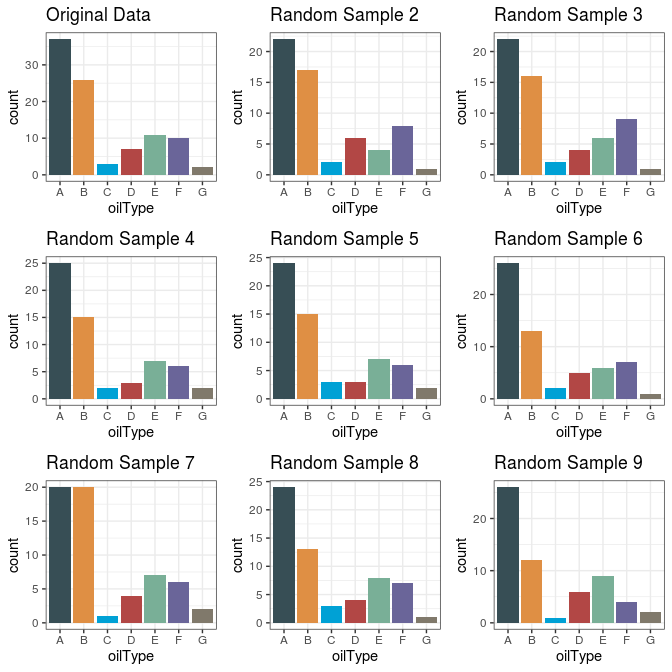

```r
cowplot::plot_grid(plotlist = G1, nrow = 3)
```

# (b)

## Using `caret::createDataPartition()`

Create 8 random samples using `createDataPartition()`and compare the distribution to the original data distribution:

```r
set.seed(1)

# Matrix of class distributions for the samples:
M2 <- matrix(0, ncol = length(levels(oilType)), nrow = num_samples)
M2[1, ] <- table(oilType) # the first row is the actual class distributions
dimnames(M2) <- list(c("Original Sample", paste0("Random Sample ", 2:num_samples)), levels(oilType))

# List of histograms for the samples:
G2 <- vector("list", length = num_samples)
G2[[1]] <- ggplot(tibble(oilType)) +
  geom_bar(aes(oilType, fill = oilType),
           show.legend = FALSE) +
  ggsci::scale_fill_jama() +
  ggtitle("Original Data") # plot the original data

# Take 8 random samples and plot:
for(i in 2:num_samples) {
  # Generate a sample:
  sample_i <- oilType[createDataPartition(oilType, p = 60/length(oilType), list = FALSE)]

  # Gather the class distributions:
  M2[i, ] <- table(sample_i)

  # Plot:
  G2[[i]] <- ggplot(tibble(oilType = sample_i)) +
  geom_bar(aes(oilType, fill = oilType),
           show.legend = FALSE) +
  ggsci::scale_fill_jama() +
  ggtitle(str_interp("Random Sample ${i}"))
}
```

By inspecting a summary of the class distributions we see that there is less variability among the samples:

```r
summary(M2)
```

```
       A              B            C              D              E               F               G
 Min.   :24.0   Min.   :17   Min.   :2.00   Min.   :5.00   Min.   : 7.00   Min.   : 7.00   Min.   :2
 1st Qu.:24.0   1st Qu.:17   1st Qu.:2.00   1st Qu.:5.00   1st Qu.: 7.00   1st Qu.: 7.00   1st Qu.:2
 Median :24.0   Median :17   Median :2.00   Median :5.00   Median : 7.00   Median : 7.00   Median :2
 Mean   :25.4   Mean   :18   Mean   :2.11   Mean   :5.22   Mean   : 7.44   Mean   : 7.33   Mean   :2
 3rd Qu.:24.0   3rd Qu.:17   3rd Qu.:2.00   3rd Qu.:5.00   3rd Qu.: 7.00   3rd Qu.: 7.00   3rd Qu.:2
 Max.   :37.0   Max.   :26   Max.   :3.00   Max.   :7.00   Max.   :11.00   Max.   :10.00   Max.   :2
```

By inspecting plots of the samples’ class distributions we see that there is less variability among the samples. Most of the plots look similar to the original data:

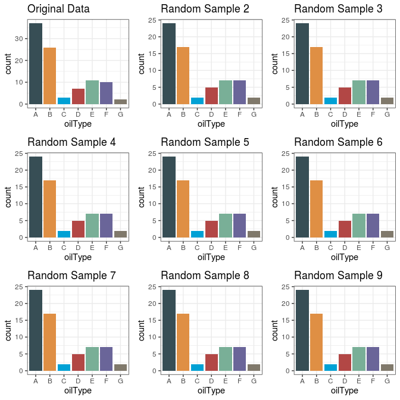

```r
cowplot::plot_grid(plotlist = G2, nrow = 3)
```

## Using `rsample::initial_split()`

The `tidymodels` package also provides a method for sampling from a data set using stratification. Create 8 random samples using `rsample::initial_split()`and compare the distribution to the original data distribution:

```r
set.seed(1)

# Matrix of class distributions for the samples:
M3 <- matrix(0, ncol = length(levels(oilType)), nrow = num_samples)
M3[1, ] <- table(oilType) # the first row is the actual class distributions
dimnames(M3) <- list(c("Original Sample", paste0("Random Sample ", 2:num_samples)), levels(oilType))

# List of histograms for the samples:
G3 <- vector("list", length = num_samples)
G3[[1]] <- ggplot(tibble(oilType)) +
  geom_bar(aes(oilType, fill = oilType),
           show.legend = FALSE) +
  ggsci::scale_fill_jama() +
  ggtitle("Original Data") # plot the original data

# Take 8 random samples and plot:
for(i in 2:num_samples) {
  # Generate a sample:
  sample_i <- oilType[rsample::initial_split(data.frame(type = oilType), strata = type, prop = 60/length(oilType)) %>% pluck("in_id")]

  # Gather the class distributions:
  M3[i, ] <- table(sample_i)

  # Plot:
  G3[[i]] <- ggplot(tibble(oilType = sample_i)) +
  geom_bar(aes(oilType, fill = oilType),
           show.legend = FALSE) +
  ggsci::scale_fill_jama() +
  ggtitle(str_interp("Random Sample ${i}"))
}
```

By inspecting a summary of the class distributions we see that there is less variability among the samples:

```r
summary(M3)
```

```
       A              B              C              D              E               F               G
 Min.   :22.0   Min.   :15.0   Min.   :1.00   Min.   :3.00   Min.   : 6.00   Min.   : 6.00   Min.   :0.00
 1st Qu.:23.0   1st Qu.:17.0   1st Qu.:2.00   1st Qu.:3.00   1st Qu.: 7.00   1st Qu.: 6.00   1st Qu.:1.00
 Median :24.0   Median :17.0   Median :2.00   Median :5.00   Median : 8.00   Median : 7.00   Median :1.00
 Mean   :24.9   Mean   :17.9   Mean   :2.11   Mean   :4.44   Mean   : 7.89   Mean   : 7.11   Mean   :1.33
 3rd Qu.:24.0   3rd Qu.:18.0   3rd Qu.:2.00   3rd Qu.:5.00   3rd Qu.: 8.00   3rd Qu.: 8.00   3rd Qu.:2.00
 Max.   :37.0   Max.   :26.0   Max.   :3.00   Max.   :7.00   Max.   :11.00   Max.   :10.00   Max.   :2.00
```

By inspecting plots of the samples’ class distributions we see that there is less variability among the samples. Most of the plots look similar to the original data. However, one of the samples failed to take any of the ‘G’ oil type. Overall the `caret` method seems to provide more representative samples than the `rsample` method, but that might just be due to the particular data set we have here.

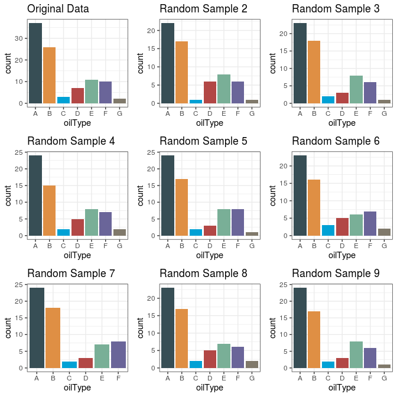

```r
cowplot::plot_grid(plotlist = G3, nrow = 3)
```

# (c)

*Adapted from Kuhn and Johnson (2013)*

Choosing a data splitting strategy is difficult. One possibility would be leave–one–out cross– validation (LOOCV) only because, with the exception of class G, each class will be represented in each re- sample. It should be noted that some classification models require at least one sample from each class, so resampling these data may place a restriction one which models can be used. As for a test set, it may be reasonable to rely on leave–one–out cross–validation as the only method for assessing performance. Indeed in the original paper, Brodnjak-Vonina et al. (2005), the authors use LOOCV to estimate the performance of their models on the training data. They achieve a very high accuracy (96.84%). Alternatively, a test set could be used if it only consisted of the classes with the most samples (e.g. A, B and maybe E and F) although this would only protect against gross overfitting.

# (d)

Calculate the width of the 95% confidence interval for one sample size and accuracy rate (this matches the result given in the exercise instructions):

```r
n <- 20
accuracy <- 0.8
binom_test <- binom.test(round(accuracy*n), n)
100*(binom_test$conf.int[2] - binom_test$conf.int[1])
```

```
[1] 37.93
```

Plot the width of the 95% confidence interval for a range of sample sizes and accuracy rates:

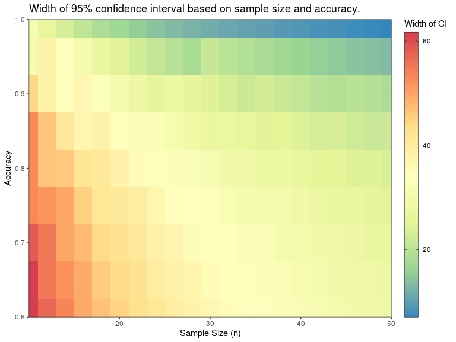

```r
n <- rep(seq(10, 50, by = 2), 5)
accuracy <- map(seq(0.60, 1, by = 0.05), ~rep(.x, 9)) %>% unlist()

out <- outer(n, accuracy, function(x, y) {
      map2_dbl(x, y, function(x, y) {
        result <- binom.test(round(x*y), x)
        return(100*(result$conf.int[2] - result$conf.int[1])) # Multiply by 100 for percentage
          }
      )
  }
)

dimnames(out) <- list(n, accuracy)
out <- out %>%
  reshape::melt() %>%
  dplyr::rename(n = X1, accuracy = X2)

ggplot(out, aes(n, accuracy)) +
  geom_raster(interpolate = F, aes(fill = value)) +
  scale_fill_distiller(name = "CI Width", type = "div", palette = 9, direction = -1) +
  scale_x_continuous(breaks = seq(n[1] + 10, n[length(n)], by = 10)) +
  scale_y_continuous(breaks = seq(accuracy[1], accuracy[length(accuracy)], by = 0.1)) +
  coord_cartesian(xlim = c(n[1], n[length(n)]), ylim = c(accuracy[1], accuracy[length(accuracy)]), expand = FALSE) +
  theme_bw() +
  labs(x = "Sample Size (n)", y = "Accuracy",
       title = "Width of 95% confidence interval based on sample size and accuracy.") +
  guides(fill = guide_colourbar("Width of CI",
                                barheight = unit(5, "in"),
                                ticks.colour = "black",
                                frame.colour = "black"))
```

[^1]: Kuhn M, Johnson K (2013). *Applied Predictive Modeling*. Springer.
[^2]: Brodnjak-Vonina D, Kodba Z, Novi M (2005). “Multivariate Data Analysis in Classification of Vegetable Oils Characterized by the Content of Fatty Acids.” Chemometrics and Intelligent Laboratory Systems, **75**(1), 31–43.